# Preprocessing Experiment 4 data

Bodo Winter & Greg Woodin

05/10/2018

## Analysis of Experiment 4

This is the analysis of Experiment 4. Start loading packages, function file and data:

```r
library(tidyverse)    # for data processing
library(stringr)    # for data processing
library(lme4)   # for mixed models
library(afex)   # for mixed models
library(lsr)   # for Cramer's V

source('../scripts/functions.R')

df <- read_csv("../data/E4_processed.csv")
df %>% print(n = 6, width = Inf)
```

```
## # A tibble: 3,104 x 12
##   ID    Handedness Gender Type  ConceptOrder Resp  Axis  Pixel
##   <chr> <chr>      <chr>  <chr>        <int> <chr> <chr> <int>
## 1 S1    Right      Female N                1 2     x       237
## 2 S1    Right      Female N                1 2     y       549
## 3 S1    Right      Female N                2 4     x       528
## 4 S1    Right      Female N                2 4     y       545
## 5 S1    Right      Female N                3 7     x       234
## 6 S1    Right      Female N                3 7     y       218
##   Exp1
##   <chr>
## 1 I put them in order of least to most with top left being least and bott…
## 2 I put them in order of least to most with top left being least and bott…
## 3 I put them in order of least to most with top left being least and bott…
## 4 I put them in order of least to most with top left being least and bott…
```

[output cut: 27 more lines]

Check how many subjects, how many male and female:

```r
# Number of subjects:

length(unique(df$ID))
```

```
## [1] 122
```

```r
# Male/female:

apply(table(df$ID, df$Gender), MARGIN = 1,
      FUN = function(x) ifelse(x[1] > 0, 'Female', 'Male')) %>% table()
```

```
## .
## Female   Male
##     46     76
```

```r
# Handedness:

hv <- c('left', 'ambi', 'right')
apply(table(df$ID, df$Handedness), MARGIN = 1,
      FUN = function(x) hv[which.max(x)]) %>% table()
```

```
## .
##  ambi  left right
##     1    11   110
```

Compute x- and y-axis ranges (across the four clicks). This is a rough indicator of axis use. We do this separately for each subject and each task (time, valence etc.)

```r
df_range <- df %>%
  group_by(ID, Type, Axis) %>%
  summarize(Min = min(Pixel),
            Max = max(Pixel)) %>%
  mutate(Range = Max - Min)
```

## Analysis of axis use via range (continuous)

First, let’s explore some descriptive stats:

```r
df_range %>% group_by(Type, Axis) %>%
    summarize(RangeM = mean(Range),
    RangeSD = sd(Range))
```

```
## # A tibble: 8 x 4
## # Groups:   Type [?]
##   Type  Axis  RangeM RangeSD
##   <chr> <chr>  <dbl>   <dbl>
## 1 N     x       279.    200.
## 2 N     y       290.    154.
## 3 Q     x       218.    201.
## 4 Q     y       376.    176.
## 5 T     x       314.    211.
## 6 T     y       308.    192.
## 7 V     x       230.    209.
## 8 V     y       373.    189.
```

Make factors for ordering in plot:

```r
df_range <- df_range %>%
  ungroup %>%
  mutate(Type = factor(Type, levels = c('T', 'Q', 'N', 'V')))
```

Make a public-ready boxplot:

```r
x_box <- boxplot(Range ~ Type,
                 data = filter(df_range, Axis == 'x'),
                 plot = FALSE)
y_box <- boxplot(Range ~ Type,
                 data = filter(df_range, Axis == 'y'),
                 plot = FALSE)
```

Set columns (both quantity and number will be red):

```r
mycols <- c('steelblue4',
            'indianred4', 'indianred4', 'goldenrod3')
```

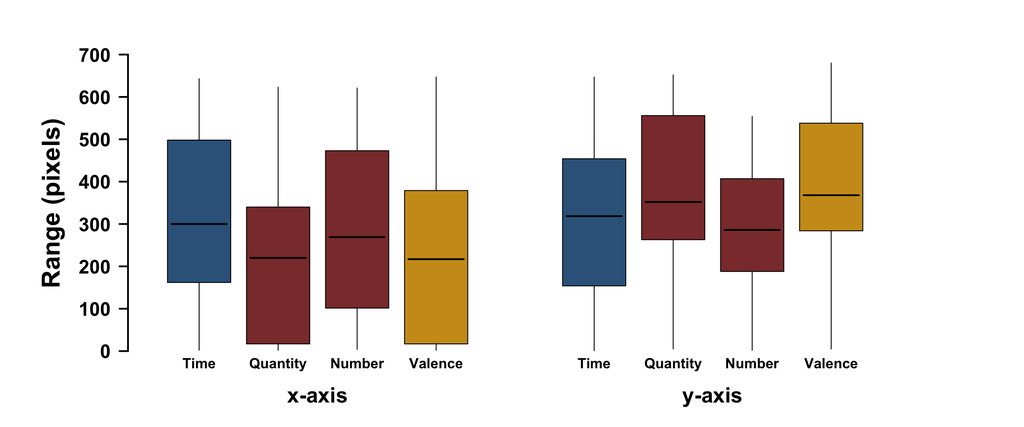

```r
xfac <- 0.1

quartz('', 12, 4)
par(mai = c(0.75, 1.5, 0.5, 0.5))
emptyplot(xlim = c(0, 10), ylim = c(0, 700))
axis(side = 2, at = seq(0, 700, 100),
    font = 2, las = 2, cex.axis = 1.35, lwd = 2)
mtext(text = 'Range (pixels)', side = 2, line = 3.8,
    font = 2, cex = 1.75)
axis(side = 1, at = seq(0.5, 3.5, 1),
    labels = c('Time', 'Quantity', 'Number', 'Valence'),
    font = 2, cex.axis = 1, line = -1.5, tick = FALSE)
axis(side = 1, at = c(2, 7),
    labels = c('x-axis', 'y-axis'),
    font = 2, cex.axis = 1.5, line = 0.5, tick = FALSE)
for (i in 1:4) {
    rect(xleft = i - 1 + xfac, xright = i - xfac,
        ybottom = x_box$stats[2, i],
        ytop = x_box$stats[4, i],
        col = mycols[i])
    segments(x0 = i - 1 + xfac + 0.05, x1 = i - xfac - 0.05,
        y0 = x_box$stats[3, i], lwd = 2)
    segments(x0 = seq(0.5, 3.5, 1)[i],
        y0 = x_box$stats[4, i],
        y1 = x_box$stats[5, i])
    segments(x0 = seq(0.5, 3.5, 1)[i],
        y1 = x_box$stats[2, i],
        y0 = x_box$stats[1, i])
    }
axis(side = 1, at = seq(0.5, 3.5, 1) + 5,
    labels = c('Time', 'Quantity', 'Number', 'Valence'),
    font = 2, cex.axis = 1, line = -1.5, tick = FALSE)
for (i in 1:4) {
    rect(xleft = i - 1 + xfac + 5, xright = i - xfac + 5,
        ybottom = y_box$stats[2, i],
        ytop = y_box$stats[4, i],
        col = mycols[i])
    segments(x0 = i - 1 + xfac + 0.05 + 5, x1 = i - xfac - 0.05 + 5,
        y0 = y_box$stats[3, i], lwd = 2)
    segments(x0 = seq(0.5, 3.5, 1)[i] + 5,
        y0 = y_box$stats[4, i],
        y1 = y_box$stats[5, i])
    segments(x0 = seq(0.5, 3.5, 1)[i] + 5,
        y1 = y_box$stats[2, i],
        y0 = y_box$stats[1, i])
}
```

Models of this, with the afex package for likelihood ratio tests:

```r
x_mdl <- mixed(Range ~ Type + (1|ID),
    data = filter(df_range, Axis == 'x'), method = 'LRT', check_contrasts = FALSE)
```

```
## Fitting 2 (g)lmer() models:
## [..]
```

```r
y_mdl <- mixed(Range ~ Type + (1|ID),
    data = filter(df_range, Axis == 'y'), method = 'LRT', check_contrasts = FALSE)
```

```
## Fitting 2 (g)lmer() models:
## [..]
```

```r
all_mdl <- mixed(Range ~ Type * Axis +
                   (1 + Axis|ID),
    data = df_range, method = 'LRT')
```

```
## Fitting 4 (g)lmer() models:
## [....]
```

Check the likelihood ratio tests results:

```r
x_mdl
```

```
## Mixed Model Anova Table (Type 3 tests, LRT-method)
##
## Model: Range ~ Type + (1 | ID)
## Data: filter
## Data: df_range
## Data: Axis == "x"
## Df full model: 6
##   Effect df     Chisq p.value
## 1   Type  3 34.37 ***  <.0001
## ---
## Signif. codes:  0 '***' 0.001 '**' 0.01 '*' 0.05 '+' 0.1 ' ' 1
```

```r
y_mdl
```

```
## Mixed Model Anova Table (Type 3 tests, LRT-method)
##
## Model: Range ~ Type + (1 | ID)
## Data: filter
## Data: df_range
## Data: Axis == "y"
## Df full model: 6
##   Effect df     Chisq p.value
## 1   Type  3 19.63 ***   .0002
## ---
## Signif. codes:  0 '***' 0.001 '**' 0.01 '*' 0.05 '+' 0.1 ' ' 1
```

```r
all_mdl
```

```
## Mixed Model Anova Table (Type 3 tests, LRT-method)
##
## Model: Range ~ Type * Axis + (1 + Axis | ID)
## Data: df_range
## Df full model: 12
##      Effect df     Chisq p.value
## 1      Type  3 33.42 ***  <.0001
## 2      Axis  1 13.58 ***   .0002
## 3 Type:Axis  3 51.08 ***  <.0001
## ---
## Signif. codes:  0 '***' 0.001 '**' 0.01 '*' 0.05 '+' 0.1 ' ' 1
```

Check the individual models:

```r
summary(x_mdl$full_model)
```

```
## Linear mixed model fit by maximum likelihood . t-tests use
##   Satterthwaite's method [lmerModLmerTest]
## Formula: Range ~ Type + (1 | ID)
##    Data: data
##
##      AIC      BIC   logLik deviance df.resid
##   5141.8   5165.5  -2564.9   5129.8      382
##
## Scaled residuals:
##      Min       1Q   Median       3Q      Max
## -2.46130 -0.55546 -0.03525  0.58021  2.39905
##
## Random effects:
##  Groups   Name        Variance Std.Dev.
##  ID       (Intercept) 21776    147.6
##  Residual             20310    142.5
## Number of obs: 388, groups:  ID, 122
##
## Fixed effects:
##             Estimate Std. Error      df t value Pr(>|t|)
## (Intercept)   319.11      19.93  283.58  16.015  < 2e-16 ***
## TypeQ        -110.72      20.57  274.36  -5.381 1.59e-07 ***
## TypeN         -31.76      21.80  279.13  -1.457    0.146
## TypeV         -93.47      21.05  275.39  -4.440 1.30e-05 ***
## ---
## Signif. codes:  0 '***' 0.001 '**' 0.01 '*' 0.05 '.' 0.1 ' ' 1
##
## Correlation of Fixed Effects:
##       (Intr) TypeQ  TypeN
## TypeQ -0.538
## TypeN -0.512  0.495
## TypeV -0.525  0.510  0.479
```

```r
summary(y_mdl$full_model)
```

```
## Linear mixed model fit by maximum likelihood . t-tests use
##   Satterthwaite's method [lmerModLmerTest]
## Formula: Range ~ Type + (1 | ID)
##    Data: data
##
##      AIC      BIC   logLik deviance df.resid
##   5104.0   5127.8  -2546.0   5092.0      382
##
## Scaled residuals:
##      Min       1Q   Median       3Q      Max
## -2.47063 -0.58010  0.06729  0.67283  2.71736
##
## Random effects:
##  Groups   Name        Variance Std.Dev.
##  ID       (Intercept)  9091     95.35
##  Residual             22665    150.55
## Number of obs: 388, groups:  ID, 122
##
## Fixed effects:
##             Estimate Std. Error     df t value Pr(>|t|)
## (Intercept)   307.54      17.74 357.27  17.340  < 2e-16 ***
## TypeQ          68.24      21.56 282.32   3.166  0.00172 **
## TypeN         -11.65      22.75 291.08  -0.512  0.60897
## TypeV          59.64      22.04 284.45   2.706  0.00721 **
## ---
## Signif. codes:  0 '***' 0.001 '**' 0.01 '*' 0.05 '.' 0.1 ' ' 1
##
## Correlation of Fixed Effects:
##       (Intr) TypeQ  TypeN
## TypeQ -0.632
## TypeN -0.603  0.495
## TypeV -0.618  0.509  0.481
```

Check the full model:

```r
summary(all_mdl$full_model)$coefficients
```

```
##              Estimate Std. Error       df   t value     Pr(>|t|)
## (Intercept) 260.12648   15.23217 120.3014 17.077437 6.026534e-34
## Type1        58.89948   13.26977 553.1379  4.438621 1.093231e-05
## Type2       -51.47900   12.87393 547.3341 -3.998702 7.243509e-05
## Type3        26.55365   13.91228 561.2430  1.908649 5.681720e-02
## Axisy        76.47304   20.17083 119.7865  3.791268 2.362049e-04
## Type1:Axisy -88.28877   18.72179 557.5973 -4.715831 3.045719e-06
## Type2:Axisy  91.16388   18.17375 550.7821  5.016239 7.119336e-07
## Type3:Axisy -67.46739   19.61230 567.0654 -3.440054 6.243701e-04
```

Sum-coding makes this quite difficult to interpret. Let’s use a treatment-coded model:

```r
xmdl <- lmer(Range ~ Type * Axis +
               (1 + Axis|ID), data = df_range)
summary(xmdl)
```

```
## Linear mixed model fit by REML. t-tests use Satterthwaite's method [
## lmerModLmerTest]
## Formula: Range ~ Type * Axis + (1 + Axis | ID)
##    Data: df_range
##
## REML criterion at convergence: 10160.4
##
## Scaled residuals:
##      Min       1Q   Median       3Q      Max
## -2.47479 -0.58354  0.01788  0.64527  2.88777
##
## Random effects:
##  Groups   Name        Variance Std.Dev. Corr
##  ID       (Intercept) 21566    146.9
##           Axisy       36118    190.0    -0.86
##  Residual             21720    147.4
## Number of obs: 776, groups:  ID, 122
##
## Fixed effects:
##             Estimate Std. Error      df t value Pr(>|t|)
## (Intercept)   319.02      20.25  317.79  15.752  < 2e-16 ***
## TypeQ        -110.37      21.26  543.74  -5.191 2.97e-07 ***
## TypeN         -32.35      22.52  553.21  -1.436    0.152
## TypeV         -92.87      21.76  545.84  -4.269 2.32e-05 ***
## Axisy         -11.81      27.59  342.05  -0.428    0.669
## TypeQ:Axisy   179.44      30.01  547.47   5.979 4.04e-09 ***
## TypeN:Axisy    20.81      31.76  558.61   0.655    0.513
## TypeV:Axisy   152.88      30.70  550.05   4.980 8.52e-07 ***
## ---
## Signif. codes:  0 '***' 0.001 '**' 0.01 '*' 0.05 '.' 0.1 ' ' 1
##
## Correlation of Fixed Effects:
##             (Intr) TypeQ  TypeN  TypeV  Axisy  TypQ:A TypN:A
## TypeQ       -0.547
## TypeN       -0.521  0.495
## TypeV       -0.534  0.510  0.479
## Axisy       -0.772  0.403  0.384  0.393
## TypeQ:Axisy  0.389 -0.711 -0.352 -0.362 -0.566
## TypeN:Axisy  0.371 -0.353 -0.712 -0.341 -0.540  0.495
## TypeV:Axisy  0.379 -0.362 -0.341 -0.711 -0.553  0.510  0.480
```

Get predictions:

```r
source('../scripts/predict.glmm.R')
all_types <- unique(df_range$Type)
all_axis <- unique(df_range$Axis)
newdata <- expand.grid(all_types, all_axis) %>%
  rename(Type = Var1, Axis = Var2) %>%
  arrange(Type)
predict.glmm(xmdl, newdata = newdata) %>%
  mutate(Range = round(Range))
```

```
##   Type Axis Range       SE       UB       LB
## 1    T    x   319 20.25269 358.7164 279.3259
## 2    T    y   307 17.57109 341.6504 272.7718
## 3    Q    x   209 19.78151 247.4270 169.8835
## 4    Q    y   376 17.05775 409.7185 342.8521
## 5    N    x   287 21.02985 327.8921 245.4551
## 6    N    y   296 18.41219 331.7640 259.5882
## 7    V    x   226 20.32700 265.9970 186.3152
## 8    V    y   367 17.65060 401.8210 332.6306
```

The model predicts quantity to be much more y-expanded. The same goes for valence. For time and number, there’s no big difference between x and y.

## Analysis of categorical classifications

Load in Greg’s classifications:

```r
E4cat <- read_csv('../data/E4_cat.csv')
E4cat %>% print(n = 4, width = Inf)
```

```
## # A tibble: 388 x 12
##   Subject Condition ConsistentAxis AxisChoice ChoiceDetailed
##   <chr>   <chr>     <chr>          <chr>      <chr>
## 1 S1      N         no             <NA>       round
## 2 S1      Q         no             <NA>       round
## 3 S1      V         no             <NA>       round
## 4 S10     N         no             vertical   predominantly_vertical
##   ConsistentAxialDirection AxialDirectionDetailed AxialDirectionHorizontal
##   <chr>                    <chr>                  <chr>
## 1 <NA>                     <NA>                   <NA>
## 2 <NA>                     <NA>                   <NA>
## 3 <NA>                     <NA>                   <NA>
## 4 <NA>                     <NA>                   <NA>
##   AxialDirectionVertical ConsistentRoundDirection RoundDirectionDetailed
##   <chr>                  <chr>                    <chr>
## 1 <NA>                   no                       <NA>
## 2 <NA>                   no                       <NA>
## 3 <NA>                   no                       <NA>
## 4 <NA>                   <NA>                     <NA>
##   SameAxis
##   <chr>
## 1 no
## 2 no
## 3 no
## 4 no
## # ... with 384 more rows
```

As was done for E2 and E3, only those that used the axis consistently contribute to the “AxisChoice” measure. This is so that responses that don’t obey any conceptual order are not counted.

```r
E4cat[which(E4cat$ConsistentAxis == 'no'), ]$AxisChoice <- NA
```

## Analysis of single versus combined axis choice

Recode horizontal and vertical to “single axis”, so that it can be contrasted with diagonal.

```r
E4cat <- mutate(E4cat,
                DiagonalVsRest = ifelse(AxisChoice == 'horizontal' | AxisChoice == 'vertical', 'single', AxisChoice))
```

Tabulate single versus diagonal choices:

```r
xtab <- table(E4cat$DiagonalVsRest)
xtab
```

```
##
## diagonal   single
##       18      146
```

Proportions:

```r
round(prop.table(xtab), 2)
```

```
##
## diagonal   single
##     0.11     0.89
```

Perform a binomial test:

```r
binom.test(xtab)
```

```
##
##  Exact binomial test
##
## data:  xtab
## number of successes = 18, number of trials = 164, p-value <
## 2.2e-16
## alternative hypothesis: true probability of success is not equal to 0.5
## 95 percent confidence interval:
##  0.06635952 0.16790797
## sample estimates:
## probability of success
##              0.1097561
```

## Consistent axis use

Let’s look at consistent axis choice overall:

```r
table(E4cat$ConsistentAxis)
```

```
##
##  no yes
## 201 166
```

```r
round(prop.table(table(E4cat$ConsistentAxis)), 2)
```

```
##
##   no  yes
## 0.55 0.45
```

Let’s look at consistent axis choice:

```r
xtab <- with(E4cat,
             table(Condition, ConsistentAxis))
xtab
```

```
##          ConsistentAxis
## Condition no yes
##         N 56  30
##         Q 49  50
##         T 51  39
##         V 45  47
```

Let’s make a table of proportions for this, with row-wise proportions (convert these to percentages):

```r
round(prop.table(xtab, 1), 2)
```

```
##          ConsistentAxis
## Condition   no  yes
##         N 0.65 0.35
##         Q 0.49 0.51
##         T 0.57 0.43
##         V 0.49 0.51
```

Let’s perform a Chi-Square test of this:

```r
chisq.test(xtab)
```

```
##
##  Pearson's Chi-squared test
##
## data:  xtab
## X-squared = 6.2329, df = 3, p-value = 0.1008
```

Not significant.

Check Cramer’s V:

```r
cramersV(xtab)
```

```
## [1] 0.1303199
```

Weak.

## Analysis of round responses

Look at number of round versus number of axial responses. This column needs to be created first:

```r
axials <- c('diagonal', 'horizontal', 'vertical')
E4cat$RoundVsAxial <- NA
E4cat <- mutate(E4cat,
                RoundVsAxial = ifelse(ChoiceDetailed %in% axials, 'axial', RoundVsAxial),
                RoundVsAxial = ifelse(ChoiceDetailed == 'round', 'round', RoundVsAxial))
```

Tabulate round vs.a xial:

```r
table(E4cat$RoundVsAxial)
```

```
##
## axial round
##   166   114
```

Proportions:

```r
round(prop.table(table(E4cat$RoundVsAxial)), 2)
```

```
##
## axial round
##  0.59  0.41
```

Binomial test:

```r
binom.test(table(E4cat$RoundVsAxial))
```

```
##
##  Exact binomial test
##
## data:  table(E4cat$RoundVsAxial)
## number of successes = 166, number of trials = 280, p-value =
## 0.002247
## alternative hypothesis: true probability of success is not equal to 0.5
## 95 percent confidence interval:
##  0.5327933 0.6509340
## sample estimates:
## probability of success
##              0.5928571
```

Look at whether there was a consistent direction (clockwise/counterclockwise) for the round responses:

```r
xtab <- table(E4cat$ConsistentRoundDirection)
xtab
```

```
##
##  no yes
##  59  55
```

Proportions:

```r
round(prop.table(xtab), 2)
```

```
##
##   no  yes
## 0.52 0.48
```

Binomial test:

```r
binom.test(xtab)
```

```
##
##  Exact binomial test
##
## data:  xtab
## number of successes = 59, number of trials = 114, p-value = 0.7789
## alternative hypothesis: true probability of success is not equal to 0.5
## 95 percent confidence interval:
##  0.4220403 0.6121138
## sample estimates:
## probability of success
##              0.5175439
```

Not significant.

Look at clockwise versus counterclockwise overall:

```r
table(E4cat$RoundDirectionDetailed)
```

```
##
## CCW  CW
##  17  38
```

```r
round(prop.table(table(E4cat$RoundDirectionDetailed)), 2)
```

```
##
##  CCW   CW
## 0.31 0.69
```

And a binomial test of this:

```r
binom.test(table(E4cat$RoundDirectionDetailed))
```

```
##
##  Exact binomial test
##
## data:  table(E4cat$RoundDirectionDetailed)
## number of successes = 17, number of trials = 55, p-value =
## 0.006456
## alternative hypothesis: true probability of success is not equal to 0.5
## 95 percent confidence interval:
##  0.1914464 0.4481297
## sample estimates:
## probability of success
##              0.3090909
```

Look at clockwise versus counterclockwise for the RoundDirectionDetailed column:

```r
xtab <- with(E4cat, table(Condition,
                  RoundDirectionDetailed))
xtab
```

```
##          RoundDirectionDetailed
## Condition CCW CW
##         N   2 24
##         Q   5  4
##         T   6  6
##         V   4  4
```

Row-wise proportions for this:

```r
prop.table(xtab, 1)
```

```
##          RoundDirectionDetailed
## Condition        CCW         CW
##         N 0.07692308 0.92307692
##         Q 0.55555556 0.44444444
##         T 0.50000000 0.50000000
##         V 0.50000000 0.50000000
```

And a test of this:

```r
chisq.test(xtab)
```

```
##
##  Pearson's Chi-squared test
##
## data:  xtab
## X-squared = 12.536, df = 3, p-value = 0.005756
```

## Axis choice

Let’s create a table of this:

```r
xtab <- with(E4cat,
             table(Condition, AxisChoice))
xtab
```

```
##          AxisChoice
## Condition diagonal horizontal vertical
##         N        4          9       17
##         Q        5          6       39
##         T        4         13       21
##         V        5          6       35
```

Let’s look at the proportions of that (row-wise proportions).

```r
round(prop.table(xtab, 1), 2)
```

```
##          AxisChoice
## Condition diagonal horizontal vertical
##         N     0.13       0.30     0.57
##         Q     0.10       0.12     0.78
##         T     0.11       0.34     0.55
##         V     0.11       0.13     0.76
```

Let’s perform a Chi-Square test of this:

```r
E4_chisq <- chisq.test(xtab)
E4_chisq
```

```
##
##  Pearson's Chi-squared test
##
## data:  xtab
## X-squared = 10.564, df = 6, p-value = 0.1028
```

Not significant.

```r
E4_chisq$stdres
```

```
##          AxisChoice
## Condition   diagonal horizontal   vertical
##         N  0.4570400  1.3853599 -1.5138897
##         Q -0.2647048 -1.8267806  1.7692405
##         T -0.1010858  2.3383688 -1.9692017
##         V -0.0271256 -1.5164178  1.3392716
```

Check Cramer’s V:

```r
cramersV(xtab)
```

```
## [1] 0.1794614
```

Weak.

## (Unplanned) Post-hoc analysis:

We suspect that the diagonal responses (evenly spread across tasks and low numbers) may mess up the results in this case. We have not planned the following analysis before the data was in: What if we restrict the Chi-Square test analysis to horizontal and vertical responses?

```r
xtab <- with(E4cat,
             table(Condition, AxisChoice))
xtab <- xtab[, -1]
chisq.test(xtab)
```

```
##
##  Pearson's Chi-squared test
##
## data:  xtab
## X-squared = 10.335, df = 3, p-value = 0.01593
```

```r
chisq.test(xtab)$stdres
```

```
##          AxisChoice
## Condition horizontal  vertical
##         N   1.507367 -1.507367
##         Q  -1.899498  1.899498
##         T   2.354417 -2.354417
##         V  -1.545863  1.545863
```

```r
cramersV(xtab)
```

```
## [1] 0.2660535
```

## Entropy

Let’s check the entropy across the three categories diagonal/horizontal/vertical.

```r
E4_tab <- table(E4cat$Condition, E4cat$AxisChoice)
entropies <- apply(E4_tab, 1, entropy)
entropies <- round(entropies, 2)
entropies
```

```
##    N    Q    T    V
## 1.37 0.98 1.34 1.03
```

Looks like time and number are the most variable. Quantity is the least variable, closely followed by valence.

## Plot with categories and entropy

Plot data:

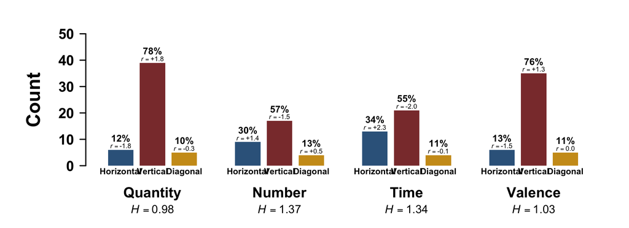

```r
# Create subsidiary tables for plotting and transpose tables for easy looping:
E4_prop <- prop.table(E4_tab, 1)
E4_percents <- t(apply(round(E4_prop * 100, 0),
    FUN = function(x) str_c(x, '%'), MARGIN = 1))
E4_stdres <- round(E4_chisq$stdres, 1)

# Plotting parameters:
xfac <- 0.1
yfac <- 4.5
yfac2 <- 1.6
yfac_bottom <- 2
mycols <- c('steelblue4', 'indianred4', 'goldenrod3')
mylabs <- c('Horizontal', 'Vertical', 'Diagonal')

# Make a nice publication-ready plot of this:
quartz('', 14, 4)
par(mai = c(1, 1.5, 0.5, 0.5))
emptyplot(xlim = c(0, 15), ylim = c(0, 50))
axis(side = 2, at = seq(0, 50, 10),
    font = 2, las = 2, cex.axis = 1.5, lwd = 2)
mtext(text = 'Count', side = 2, line = 3.8,
    font = 2, cex = 2)
axis(side = 1, at = c(2, 6, 10, 14) - 0.5,
    labels = c('Quantity', 'Number', 'Time', 'Valence'),
    font = 2, cex.axis = 1.5, line = 0.5, tick = FALSE)
axis(side = 1, at = 2 - 0.5,
    labels = bquote(italic('H')==.(entropies[2])),
    font = 2, cex.axis = 1.20, line = 1.9, tick = FALSE)
axis(side = 1, at = 6 - 0.5,
    labels = bquote(italic('H')==.(entropies[1])),
    font = 2, cex.axis = 1.2, line = 1.9, tick = FALSE)
axis(side = 1, at = 10 - 0.5,
    labels = bquote(italic('H')==.(entropies[3])),
    font = 2, cex.axis = 1.2, line = 1.9, tick = FALSE)
axis(side = 1, at = 14 - 0.5,
    labels = bquote(italic('H')==.(entropies[4])),
    font = 2, cex.axis = 1.2, line = 1.9, tick = FALSE)

# Quantity bars:
this_row <- row.names(E4_tab) == 'Q'
col_seq <- c(2, 3, 1)
for (i in 1:3) {
  mycol <- col_seq[i]
    rect(xleft = i - 1 + xfac, xright = i - xfac,
        ybottom = 0, ytop = E4_tab[this_row, mycol],
        col = mycols[i], border = NA)
    text(x = i - 0.5, y = E4_tab[this_row, mycol] + yfac,
        labels = E4_percents[this_row, mycol],
        font = 2)

    # Fix stdres values for presentation:
    this_stdres <- E4_stdres[this_row, mycol]
    stdres_display <- this_stdres
    if (this_stdres %% 1 == 0) {
        stdres_display <- str_c(stdres_display, '.0')
    }
    if (this_stdres > 0) {
        stdres_display <- str_c('+', as.character(stdres_display))
    }
    text(x = i - 0.5, y = E4_tab[this_row, mycol] + yfac2,
        labels = bquote(italic('r')==.(stdres_display)),
        font = 2, cex = 0.7)
    text(x = i - 0.5, y = 0 - yfac_bottom,
        labels = mylabs[i], adj = c(0.5, 0.5),
        font = 2, cex = 0.9, xpd = NA)
}

# Number bars:
this_row <- row.names(E4_tab) == 'N'
col_seq <- c(2, 3, 1)
xshift <- 4
for (i in 1:3) {
  mycol <- col_seq[i]
    rect(xleft = i - 1 + xfac + xshift,
         xright = i - xfac + xshift,
        ybottom = 0, ytop = E4_tab[this_row, mycol],
        col = mycols[i], border = NA)
    text(x = i - 0.5 + xshift, y = E4_tab[this_row, mycol] + yfac,
        labels = E4_percents[this_row, mycol],
        font = 2)

    # Fix stdres values for presentation:
    this_stdres <- E4_stdres[this_row, mycol]
    stdres_display <- this_stdres
    if (this_stdres %% 1 == 0) {
        stdres_display <- str_c(stdres_display, '.0')
    }
    if (this_stdres > 0) {
        stdres_display <- str_c('+', as.character(stdres_display))
    }
    text(x = i - 0.5 + xshift,
         y = E4_tab[this_row, mycol] + yfac2,
        labels = bquote(italic('r')==.(stdres_display)),
        font = 2, cex = 0.7)
    text(x = i - 0.5 + xshift, y = 0 - yfac_bottom,
        labels = mylabs[i], adj = c(0.5, 0.5),
        font = 2, cex = 0.9, xpd = NA)
}

# Time bars:
this_row <- row.names(E4_tab) == 'T'
col_seq <- c(2, 3, 1)
xshift <- 8
for (i in 1:3) {
  mycol <- col_seq[i]
    rect(xleft = i - 1 + xfac + xshift,
         xright = i - xfac + xshift,
        ybottom = 0, ytop = E4_tab[this_row, mycol],
        col = mycols[i], border = NA)
    text(x = i - 0.5 + xshift, y = E4_tab[this_row, mycol] + yfac,
        labels = E4_percents[this_row, mycol],
        font = 2)

    # Fix stdres values for presentation:
    this_stdres <- E4_stdres[this_row, mycol]
    stdres_display <- this_stdres
    if (this_stdres %% 1 == 0) {
        stdres_display <- str_c(stdres_display, '.0')
    }
    if (this_stdres > 0) {
        stdres_display <- str_c('+', as.character(stdres_display))
    }
    text(x = i - 0.5 + xshift,
         y = E4_tab[this_row, mycol] + yfac2,
        labels = bquote(italic('r')==.(stdres_display)),
        font = 2, cex = 0.7)
    text(x = i - 0.5 + xshift, y = 0 - yfac_bottom,
        labels = mylabs[i], adj = c(0.5, 0.5),
        font = 2, cex = 0.9, xpd = NA)
}

# Valence bars:
this_row <- row.names(E4_tab) == 'V'
col_seq <- c(2, 3, 1)
xshift <- 12
for (i in 1:3) {
  mycol <- col_seq[i]
    rect(xleft = i - 1 + xfac + xshift,
         xright = i - xfac + xshift,
        ybottom = 0, ytop = E4_tab[this_row, mycol],
        col = mycols[i], border = NA)
    text(x = i - 0.5 + xshift, y = E4_tab[this_row, mycol] + yfac,
        labels = E4_percents[this_row, mycol],
        font = 2)

    # Fix stdres values for presentation:
    this_stdres <- E4_stdres[this_row, mycol]
    stdres_display <- this_stdres
    if (this_stdres %% 1 == 0) {
        stdres_display <- str_c(stdres_display, '.0')
    }
    if (this_stdres > 0) {
        stdres_display <- str_c('+', as.character(stdres_display))
    }
    text(x = i - 0.5 + xshift,
         y = E4_tab[this_row, mycol] + yfac2,
        labels = bquote(italic('r')==.(stdres_display)),
        font = 2, cex = 0.7)
    text(x = i - 0.5 + xshift, y = 0 - yfac_bottom,
        labels = mylabs[i], adj = c(0.5, 0.5),
        font = 2, cex = 0.9, xpd = NA)
}
```

## Dominant direction

Let’s look at dominant direction, for horizontal overall:

```r
table(E4cat$AxialDirectionHorizontal)
```

```
##
## left-to-right right-to-left
##            36             6
```

```r
round(prop.table(table(E4cat$AxialDirectionHorizontal)), 2)
```

```
##
## left-to-right right-to-left
##          0.86          0.14
```

For horizontal by task:

```r
xtab <- with(E4cat,
     table(Condition, AxialDirectionHorizontal))
xtab
```

```
##          AxialDirectionHorizontal
## Condition left-to-right right-to-left
##         N            10             1
##         Q             6             2
##         T            13             1
##         V             7             2
```

```r
round(prop.table(xtab, 1), 2)
```

```
##          AxialDirectionHorizontal
## Condition left-to-right right-to-left
##         N          0.91          0.09
##         Q          0.75          0.25
##         T          0.93          0.07
##         V          0.78          0.22
```

Entropy of that:

```r
xtab <- with(E4cat,
     table(Condition, AxialDirectionHorizontal))
round(apply(xtab, 1, entropy), 2)
```

```
##    N    Q    T    V
## 0.44 0.81 0.37 0.76
```

For vertical overall:

```r
table(E4cat$AxialDirectionVertical)
```

```
##
## down-to-up up-to-down
##         60         22
```

```r
round(prop.table(table(E4cat$AxialDirectionVertical)), 2)
```

```
##
## down-to-up up-to-down
##       0.73       0.27
```

For vertical by task:

```r
xtab <- with(E4cat,
     table(Condition, AxialDirectionVertical))
xtab
```

```
##          AxialDirectionVertical
## Condition down-to-up up-to-down
##         N         10          5
##         Q         24          4
##         T          7          8
##         V         19          5
```

```r
round(prop.table(xtab, 1), 2)
```

```
##          AxialDirectionVertical
## Condition down-to-up up-to-down
##         N       0.67       0.33
##         Q       0.86       0.14
##         T       0.47       0.53
##         V       0.79       0.21
```

Entropy of that:

```r
xtab <- with(E4cat,
     table(Condition, AxialDirectionVertical))
round(apply(xtab, 1, entropy), 2)
```

```
##    N    Q    T    V
## 0.92 0.59 1.00 0.74
```

Let’s look at detailed responses.

```r
table(E4cat$AxialDirectionDetailed)
```

```
##
## down-left-to-up-right down-right-to-up-left            down-to-up
##                     3                     1                    56
##         left-to-right         right-to-left up-left-to-down-right
##                    30                     3                     2
## up-right-to-down-left            up-to-down
##                     3                    17
```

## Analysis of interview data

Load in interview data:

```r
E4qual <- read_csv('../data/E4_IT.csv')
```

- maths & numbers together “AllMaths”
- environment
- radial / bullseye
- clock
- timeline
- writing

For all the sections headed with “Interview:”, the counts and proportions are pooled across all participants (counts/proportions of trials overall).

## Interview: Maths / numbers

Combine maths and numbers for allmaths. For the numbers task this does not need to be done because it’s always about numbers anyway and this has been coded in the “NumbersNumber” column.

```r
E4qual <- mutate(E4qual,
                 TimeAllMath = ifelse(TimeMaths == 'yes' | TimeNumber == 'yes', 'yes', 'no'),
                 QuantityAllMath = ifelse(QuantityMaths == 'yes' | QuantityNumber == 'yes', 'yes', 'no'),
                 ValenceAllMath = ifelse(ValenceMaths == 'yes' | ValenceNumber == 'yes', 'yes', 'no'))
```

Let’s look at this:

```r
# Time:

table(E4qual$TimeAllMath)
```

```
##
##  no yes
## 120   2
```

```r
round(prop.table(table(E4qual$TimeAllMath)), 2)
```

```
##
##   no  yes
## 0.98 0.02
```

```r
# Valence:

table(E4qual$ValenceAllMath)
```

```
##
##  no yes
## 119   3
```

```r
round(prop.table(table(E4qual$ValenceAllMath)), 2)
```

```
##
##   no  yes
## 0.98 0.02
```

```r
# Quantity:

table(E4qual$QuantityAllMath)
```

```
##
##  no yes
## 119   3
```

```r
round(prop.table(table(E4qual$QuantityAllMath)), 2)
```

```
##
##   no  yes
## 0.98 0.02
```

```r
# Number:

table(E4qual$NumbersMaths)
```

```
##
##  no yes
## 117   5
```

```r
round(prop.table(table(E4qual$NumbersMaths)), 2)
```

```
##
##   no  yes
## 0.96 0.04
```

## Interview: Environment

Overall environment per condition:

```r
# Time:

table(E4qual$TimeEnvironment)
```

```
##
##  no yes
## 121   1
```

```r
round(prop.table(table(E4qual$TimeEnvironment)), 2)
```

```
##
##   no  yes
## 0.99 0.01
```

```r
# Valence:

table(E4qual$ValenceEnvironment)
```

```
##
##  no yes
## 121   1
```

```r
round(prop.table(table(E4qual$ValenceEnvironment)), 2)
```

```
##
##   no  yes
## 0.99 0.01
```

```r
# Quantity:

table(E4qual$QuantityEnvironment)
```

```
##
##  no yes
## 115   7
```

```r
round(prop.table(table(E4qual$QuantityEnvironment)), 2)
```

```
##
##   no  yes
## 0.94 0.06
```

```r
# Number:

table(E4qual$NumbersEnvironment)
```

```
##
##  no yes
## 121   1
```

```r
round(prop.table(table(E4qual$NumbersEnvironment)), 2)
```

```
##
##   no  yes
## 0.99 0.01
```

## Interview: Timeline

Overall Timeline per condition:

```r
# Time:

table(E4qual$TimeTimeline)
```

```
##
##  no yes
## 116   6
```

```r
round(prop.table(table(E4qual$TimeTimeline)), 2)
```

```
##
##   no  yes
## 0.95 0.05
```

```r
# Valence:

table(E4qual$ValenceTimeline)
```

```
##
##  no
## 122
```

```r
round(prop.table(table(E4qual$ValenceTimeline)), 2)
```

```
##
## no
##  1
```

```r
# Quantity:

table(E4qual$QuantityTimeline)
```

```
##
##  no
## 122
```

```r
round(prop.table(table(E4qual$QuantityTimeline)), 2)
```

```
##
## no
##  1
```

```r
# Number:

table(E4qual$NumbersTimeline)
```

```
##
##  no
## 122
```

```r
round(prop.table(table(E4qual$NumbersTimeline)), 2)
```

```
##
## no
##  1
```

## Interview: Writing

Overall Writing per condition:

```r
# Time:

table(E4qual$TimeWriting)
```

```
##
##  no yes
## 121   1
```

```r
round(prop.table(table(E4qual$TimeWriting)), 2)
```

```
##
##   no  yes
## 0.99 0.01
```

```r
# Valence:

table(E4qual$ValenceWriting)
```

```
##
##  no
## 122
```

```r
round(prop.table(table(E4qual$ValenceWriting)), 2)
```

```
##
## no
##  1
```

```r
# Quantity:

table(E4qual$QuantityWriting)
```

```
##
##  no
## 122
```

```r
round(prop.table(table(E4qual$QuantityWriting)), 2)
```

```
##
## no
##  1
```

```r
# Number:

table(E4qual$NumbersWriting)
```

```
##
##  no
## 122
```

```r
round(prop.table(table(E4qual$NumbersWriting)), 2)
```

```
##
## no
##  1
```

## Interview: Radial

Overall Radial per condition:

```r
# Time:

table(E4qual$TimeRadial)
```

```
##
##  no yes
## 116   6
```

```r
round(prop.table(table(E4qual$TimeRadial)), 2)
```

```
##
##   no  yes
## 0.95 0.05
```

```r
# Valence:

table(E4qual$ValenceRadial)
```

```
##
##  no yes
## 110  12
```

```r
round(prop.table(table(E4qual$ValenceRadial)), 2)
```

```
##
##  no yes
## 0.9 0.1
```

```r
# Quantity:

table(E4qual$QuantityRadial)
```

```
##
##  no yes
## 108  14
```

```r
round(prop.table(table(E4qual$QuantityRadial)), 2)
```

```
##
##   no  yes
## 0.89 0.11
```

```r
# Number:

table(E4qual$NumbersRadial)
```

```
##
##  no yes
## 116   6
```

```r
round(prop.table(table(E4qual$NumbersRadial)), 2)
```

```
##
##   no  yes
## 0.95 0.05
```

## Interview: Clock

Overall clock per condition:

```r
# Time:

table(E4qual$TimeClock)
```

```
##
##  no yes
## 113   9
```

```r
round(prop.table(table(E4qual$TimeClock)), 2)
```

```
##
##   no  yes
## 0.93 0.07
```

```r
# Valence:

table(E4qual$ValenceClock)
```

```
##
##  no yes
## 118   4
```

```r
round(prop.table(table(E4qual$ValenceClock)), 2)
```

```
##
##   no  yes
## 0.97 0.03
```

```r
# Quantity:

table(E4qual$QuantityClock)
```

```
##
##  no yes
## 118   4
```

```r
round(prop.table(table(E4qual$QuantityClock)), 2)
```

```
##
##   no  yes
## 0.97 0.03
```

```r
# Number:

table(E4qual$NumbersClock)
```

```
##
##  no yes
## 103  19
```

```r
round(prop.table(table(E4qual$NumbersClock)), 2)
```

```
##
##   no  yes
## 0.84 0.16
```

## Interview: Bullseye

Overall Bullseye per condition:

```r
# Time:

table(E4qual$TimeBullseye)
```

```
##
##  no
## 122
```

```r
round(prop.table(table(E4qual$TimeBullseye)), 2)
```

```
##
## no
##  1
```

```r
# Valence:

table(E4qual$ValenceBullseye)
```

```
##
##  no yes
## 119   3
```

```r
round(prop.table(table(E4qual$ValenceBullseye)), 2)
```

```
##
##   no  yes
## 0.98 0.02
```

```r
# Quantity:

table(E4qual$QuantityBullseye)
```

```
##
##  no yes
## 121   1
```

```r
round(prop.table(table(E4qual$QuantityBullseye)), 2)
```

```
##
##   no  yes
## 0.99 0.01
```

```r
# Number:

table(E4qual$NumbersBullseye)
```

```
##
##  no yes
## 119   3
```

```r
round(prop.table(table(E4qual$NumbersBullseye)), 2)
```

```
##
##   no  yes
## 0.98 0.02
```

## Relationship between interviews and axes

This part is exploratory. There are lots of associations between the interview data and the responses to look at. We are going to focus on results that stand out to us, or that are theoretically interesting.

Merge the two datasets:

```r
E4both <- left_join(E4cat, E4qual)
```

## Interview & response: Clock & round responses

Round vs axial, don’t mind the fact that the table says QuantityClock, it’s across all trials:

```r
Q_clock <- with(filter(E4both, Condition == 'Q'),
     table(QuantityClock, RoundVsAxial))
Q_clock
```

```
##              RoundVsAxial
## QuantityClock axial round
##           no     51    20
##           yes     0     4
```

```r
N_clock <- with(filter(E4both, Condition == 'N'),
     table(NumbersClock, RoundVsAxial))
N_clock
```

```
##             RoundVsAxial
## NumbersClock axial round
##          no     31    20
##          yes     0    18
```

```r
T_clock <- with(filter(E4both, Condition == 'T'),
     table(TimeClock, RoundVsAxial))
T_clock
```

```
##          RoundVsAxial
## TimeClock axial round
##       no     38    19
##       yes     0     7
```

```r
V_clock <- with(filter(E4both, Condition == 'V'),
     table(ValenceClock, RoundVsAxial))
V_clock
```

```
##             RoundVsAxial
## ValenceClock axial round
##          no     46    22
##          yes     0     4
```

```r
xtab <- Q_clock + N_clock + T_clock + V_clock
xtab
```

```
##              RoundVsAxial
## QuantityClock axial round
##           no    166    81
##           yes     0    33
```

```r
prop.table(xtab, 1)
```

```
##              RoundVsAxial
## QuantityClock     axial     round
##           no  0.6720648 0.3279352
##           yes 0.0000000 1.0000000
```

Same for axis choice:

```r
Q_clock <- with(filter(E4both, Condition == 'Q'),
     table(QuantityClock, AxisChoice))
Q_clock
```

```
##              AxisChoice
## QuantityClock diagonal horizontal vertical
##           no         5          6       39
##           yes        0          0        0
```

```r
N_clock <- with(filter(E4both, Condition == 'N'),
     table(NumbersClock, AxisChoice))
N_clock
```

```
##             AxisChoice
## NumbersClock diagonal horizontal vertical
##          no         4          9       17
##          yes        0          0        0
```

```r
T_clock <- with(filter(E4both, Condition == 'T'),
     table(TimeClock, AxisChoice))
T_clock
```

```
##          AxisChoice
## TimeClock diagonal horizontal vertical
##       no         4         13       21
##       yes        0          0        0
```

```r
V_clock <- with(filter(E4both, Condition == 'V'),
     table(ValenceClock, AxisChoice))
V_clock
```

```
##             AxisChoice
## ValenceClock diagonal horizontal vertical
##          no         5          6       35
##          yes        0          0        0
```

```r
xtab <- Q_clock + N_clock + T_clock + V_clock
xtab
```

```
##              AxisChoice
## QuantityClock diagonal horizontal vertical
##           no        18         34      112
##           yes        0          0        0
```

```r
prop.table(xtab, 1)
```

```
##              AxisChoice
## QuantityClock  diagonal horizontal  vertical
##           no  0.1097561  0.2073171 0.6829268
##           yes
```

Of course, then it makes no sense to look at axis choice, because those who mentioned clocks for those trials responded roundly anyway.

Same for counter clockwise versus clockwise:

```r
Q_clock <- with(filter(E4both, Condition == 'Q'),
     table(QuantityClock, RoundDirectionDetailed))
Q_clock
```

```
##              RoundDirectionDetailed
## QuantityClock CCW CW
##           no    4  3
##           yes   1  1
```

```r
N_clock <- with(filter(E4both, Condition == 'N'),
     table(NumbersClock, RoundDirectionDetailed))
N_clock
```

```
##             RoundDirectionDetailed
## NumbersClock CCW CW
##          no    2  9
##          yes   0 15
```

```r
T_clock <- with(filter(E4both, Condition == 'T'),
     table(TimeClock, RoundDirectionDetailed))
T_clock
```

```
##          RoundDirectionDetailed
## TimeClock CCW CW
##       no    6  3
##       yes   0  3
```

```r
V_clock <- with(filter(E4both, Condition == 'V'),
     table(ValenceClock, RoundDirectionDetailed))
V_clock
```

```
##             RoundDirectionDetailed
## ValenceClock CCW CW
##          no    3  4
##          yes   1  0
```

```r
xtab <- Q_clock + N_clock + T_clock + V_clock
xtab
```

```
##              RoundDirectionDetailed
## QuantityClock CCW CW
##           no   15 19
##           yes   2 19
```

```r
prop.table(xtab, 1)
```

```
##              RoundDirectionDetailed
## QuantityClock       CCW        CW
##           no  0.4411765 0.5588235
##           yes 0.0952381 0.9047619
```

## Interview & response: Vertical & axis & environment

```r
Q_Environment <- with(filter(E4both, Condition == 'Q'),
     table(QuantityEnvironment, RoundVsAxial))
Q_Environment
```

```
##                    RoundVsAxial
## QuantityEnvironment axial round
##                 no     45    23
##                 yes     6     1
```

```r
N_Environment <- with(filter(E4both, Condition == 'N'),
     table(NumbersEnvironment, RoundVsAxial))
N_Environment
```

```
##                   RoundVsAxial
## NumbersEnvironment axial round
##                no     31    38
##                yes     0     0
```

```r
T_Environment <- with(filter(E4both, Condition == 'T'),
     table(TimeEnvironment, RoundVsAxial))
T_Environment
```

```
##                RoundVsAxial
## TimeEnvironment axial round
##             no     38    26
##             yes     0     0
```

```r
V_Environment <- with(filter(E4both, Condition == 'V'),
     table(ValenceEnvironment, RoundVsAxial))
V_Environment
```

```
##                   RoundVsAxial
## ValenceEnvironment axial round
##                no     45    26
##                yes     1     0
```

```r
xtab <- Q_Environment + N_Environment + T_Environment + V_Environment
xtab
```

```
##                    RoundVsAxial
## QuantityEnvironment axial round
##                 no    159   113
##                 yes     7     1
```

```r
prop.table(xtab, 1)
```

```
##                    RoundVsAxial
## QuantityEnvironment     axial     round
##                 no  0.5845588 0.4154412
##                 yes 0.8750000 0.1250000
```

This is for all!

Same for axis choice:

```r
Q_Environment <- with(filter(E4both, Condition == 'Q'),
     table(QuantityEnvironment, AxisChoice))
N_Environment <- with(filter(E4both, Condition == 'N'),
     table(NumbersEnvironment, AxisChoice))
T_Environment <- with(filter(E4both, Condition == 'T'),
     table(TimeEnvironment, AxisChoice))
V_Environment <- with(filter(E4both, Condition == 'V'),
     table(ValenceEnvironment, AxisChoice))
xtab <- Q_Environment + N_Environment + T_Environment + V_Environment
xtab
```

```
##                    AxisChoice
## QuantityEnvironment diagonal horizontal vertical
##                 no        17         34      107
##                 yes        1          0        5
```

```r
prop.table(xtab, 1)
```

```
##                    AxisChoice
## QuantityEnvironment  diagonal horizontal  vertical
##                 no  0.1075949  0.2151899 0.6772152
##                 yes 0.1666667  0.0000000 0.8333333
```

This is for all!

## Interview & response: Timeline & horizontal

Time line mentioning and horizontal responses.

```r
Q_Timeline <- with(filter(E4both, Condition == 'Q'),
     table(QuantityTimeline, RoundVsAxial))
Q_Timeline
```

```
##                 RoundVsAxial
## QuantityTimeline axial round
##               no    51    24
```

```r
N_Timeline <- with(filter(E4both, Condition == 'N'),
     table(NumbersTimeline, RoundVsAxial))
N_Timeline
```

```
##                RoundVsAxial
## NumbersTimeline axial round
##              no    31    38
```

```r
T_Timeline <- with(filter(E4both, Condition == 'T'),
     table(TimeTimeline, RoundVsAxial))
T_Timeline
```

```
##             RoundVsAxial
## TimeTimeline axial round
##          no     32    26
##          yes     6     0
```

```r
V_Timeline <- with(filter(E4both, Condition == 'V'),
     table(ValenceTimeline, RoundVsAxial))
V_Timeline
```

```
##                RoundVsAxial
## ValenceTimeline axial round
##              no    46    26
```

```r
xtab <- Q_Timeline + N_Timeline + T_Timeline[1, ] + V_Timeline
xtab <- rbind(xtab, T_Timeline[2, ])
row.names(xtab) <- c('no', 'yes')
xtab
```

```
##     axial round
## no    160   114
## yes     6     0
```

```r
prop.table(xtab, 1)
```

```
##         axial     round
## no  0.5839416 0.4160584
## yes 1.0000000 0.0000000
```

Same for axis choice:

```r
Q_Timeline <- with(filter(E4both, Condition == 'Q'),
     table(QuantityTimeline, AxisChoice))
Q_Timeline
```

```
##                 AxisChoice
## QuantityTimeline diagonal horizontal vertical
##               no        5          6       39
```

```r
N_Timeline <- with(filter(E4both, Condition == 'N'),
     table(NumbersTimeline, AxisChoice))
N_Timeline
```

```
##                AxisChoice
## NumbersTimeline diagonal horizontal vertical
##              no        4          9       17
```

```r
T_Timeline <- with(filter(E4both, Condition == 'T'),
     table(TimeTimeline, AxisChoice))
T_Timeline
```

```
##             AxisChoice
## TimeTimeline diagonal horizontal vertical
##          no         4          8       20
##          yes        0          5        1
```

```r
V_Timeline <- with(filter(E4both, Condition == 'V'),
     table(ValenceTimeline, AxisChoice))
V_Timeline
```

```
##                AxisChoice
## ValenceTimeline diagonal horizontal vertical
##              no        5          6       35
```

```r
xtab <- Q_Timeline + N_Timeline + T_Timeline[1, ] + V_Timeline
xtab <- rbind(xtab, T_Timeline[2, ])
row.names(xtab) <- c('no', 'yes')
xtab
```

```
##     diagonal horizontal vertical
## no        18         29      111
## yes        0          5        1
```

```r
prop.table(xtab, 1)
```

```
##      diagonal horizontal  vertical
## no  0.1139241  0.1835443 0.7025316
## yes 0.0000000  0.8333333 0.1666667
```

Almost all were horizontal for those who mentioned timelines, and that was in the time condition.